# Regression_2019111233_MLBStats

### 해석

> 우리의 관심사인 타겟 변수 WR과 다른 변수들간의 상관 관계는 다음과 같은 요소들과 강한 상관 관계를 보이고 있음을 알 수 있다.

[output not shown]

#### WR - OBP : 승률과 출루율의 관계

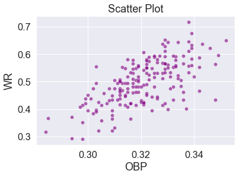

```python
sns.scatterplot(data=df, x='OBP', y='WR', markers='o', color='purple', alpha=0.6)
plt.title('Scatter Plot')
plt.show()
```

#### 해설

- 팀의 승률이 출루율과 양의 상관 관계를 가지므로 출루율이 높은 팀들이 상대적으로 더 높은 승률을 보입니다.

#### WR - BB : 승률과 볼넷의 관계

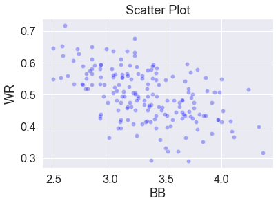

```python
sns.scatterplot(data=df, x='BB', y='WR', markers='o', color='blue', alpha=0.3)
plt.title('Scatter Plot')
plt.show()
```

#### 해설

- 팀의 승률이 볼넷 개수와 음의 상관 관계를 가지므로 볼넷의 수가 많은 팀들이 상대적으로 더 낮은 승률을 보입니다.

#### 팀별 차이 탐색

여러 팀이 연도별로 구별되어 나누어져 있는 데이터이기 때문에 팀 간의 차이가 궁금해져서 팀 별 변수 값을 확인해봅니다.

1. Tm : 팀 이름(연도별로 구별)
2. HR : 홈런
3. CS : 도루 실패 비율
4. BA : 타율
5. OBP : 출루율
6. GDP : 병살타 수
7. SF : 희생 플라이 수
8. WR : 승률 (중앙값)
9. ERR : 실책률
10. ERA : 투수의 평균 자책점
11. BB : 볼넷 / 사구 수
12. TEAM : 소속 팀

```python
### 각 팀 데이터 갯수 살펴보기
### 총 6년 간의 데이터를 각 팀별로 구분해 놓은 것이므로 모두 6개씩의 데이터 존재
### 히스토그램은 출력하지 않았음
df['TEAM'].value_counts()

### 해설
### 6개씩 총 30팀 존재
```

```
Arizona Diamondbacks     6
Atlanta Braves           6
Toronto Blue Jays        6
Texas Rangers            6
Tampa Bay Rays           6
St. Louis Cardinals      6
San Francisco Giants     6
Seattle Mariners         6
San Diego Padres         6
Pittsburgh Pirates       6
Philadelphia Phillies    6
Oakland Athletics        6
New York Yankees         6
New York Mets            6
Minnesota Twins          6
Milwaukee Brewers        6
Miami Marlins            6
Los Angeles Dodgers      6
Los Angeles Angels       6
Kansas City Royals       6
Houston Astros           6
Detroit Tigers           6
Colorado Rockies         6
Cleveland Indians        6
Cincinnati Reds          6
Chicago White Sox        6
Chicago Cubs             6
Boston Red Sox           6
Baltimore Orioles        6
Washington Nationals     6
Name: TEAM, dtype: int64
```

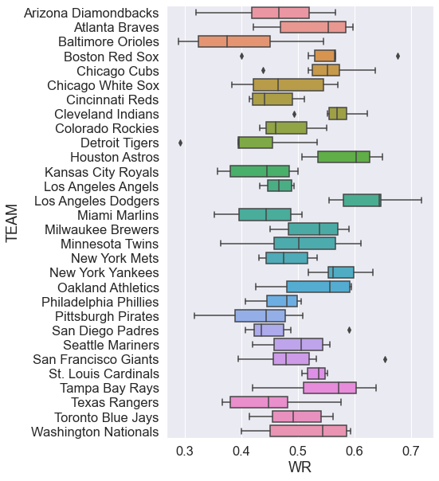

```python
### boxplo을 활용하여 팀별 승률 특징 시각화
fig = plt.figure(figsize=(6,10))
sns.boxplot(x='WR', y='TEAM', data=df)
```

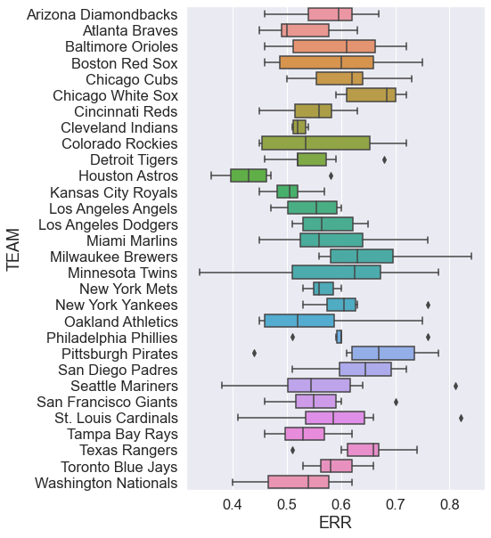

```python
### 팀별 실책률을 시각화
fig = plt.figure(figsize=(6,10))
sns.boxplot(x='ERR', y='TEAM', data=df)
```

#### 해설

##### 팀별 승률 시각화와 팀별 실책률 그림을 비교

변수들을 활용하여 각 팀의 승률을 예측하는 회귀 모델 제작

##### 3-1 데이터 전처리

먼저 Feature 들의 scale 차이를 없애기 위해 수치형 Feature에 대해서 표준화를 진행해야 합니다.

```python
df.head()
```

|  | Tm | HR | CS | BA | OBP | GDP | SF | WR | ERR | ERA | BB | TEAM |
| --- | --- | --- | --- | --- | --- | --- | --- | --- | --- | --- | --- | --- |
| 0 | Arizona Diamondbacks 2021 | 0.89 | 0.10 | 0.236 | 0.309 | 0.61 | 0.17 | 0.321 | 0.62 | 5.12 | 3.52 | Arizona Diamondbacks |
| 1 | Atlanta Braves 2021 | 1.48 | 0.11 | 0.244 | 0.319 | 0.50 | 0.25 | 0.559 | 0.45 | 3.82 | 3.29 | Atlanta Braves |
| 2 | Baltimore Orioles 2021 | 1.20 | 0.14 | 0.239 | 0.304 | 0.65 | 0.19 | 0.321 | 0.46 | 5.85 | 3.61 | Baltimore Orioles |
| 3 | Boston Red Sox 2021 | 1.39 | 0.13 | 0.261 | 0.328 | 0.65 | 0.25 | 0.567 | 0.66 | 4.30 | 3.41 | Boston Red Sox |
| 4 | Chicago Cubs 2021 | 1.30 | 0.23 | 0.237 | 0.312 | 0.82 | 0.19 | 0.438 | 0.54 | 4.87 | 3.80 | Chicago Cubs |

```python
df.info()
```

```
<class 'pandas.core.frame.DataFrame'>
RangeIndex: 180 entries, 0 to 179
Data columns (total 12 columns):
 #   Column  Non-Null Count  Dtype
---  ------  --------------  -----
 0   Tm      180 non-null    object
 1   HR      180 non-null    float64
 2   CS      180 non-null    float64
 3   BA      180 non-null    float64
 4   OBP     180 non-null    float64
 5   GDP     180 non-null    float64
 6   SF      180 non-null    float64
 7   WR      180 non-null    float64
 8   ERR     180 non-null    float64
 9   ERA     180 non-null    float64
 10  BB      180 non-null    float64
 11  TEAM    180 non-null    object
dtypes: float64(10), object(2)
memory usage: 17.0+ KB
```

```python
### 문자형 변수인 "Tm"과 “TEAM”을 제외하고 모든 수치형 변수에 대해서 표준화 진행
from sklearn.preprocessing import StandardScaler

scaler = StandardScaler()
scale_columns = ['HR', 'CS', 'BA', 'OBP', 'GDP', 'SF', 'ERR', 'ERA', 'BB']
df[scale_columns] = scaler.fit_transform(df[scale_columns])
```

```python
df.head()
```

|  | Tm | HR | CS | BA | OBP | GDP | SF | WR | ERR | ERA | BB | TEAM |
| --- | --- | --- | --- | --- | --- | --- | --- | --- | --- | --- | --- | --- |
| 0 | Arizona Diamondbacks 2021 | -1.570465 | -1.453096 | -1.125884 | -0.921234 | -1.075433 | -1.430400 | 0.321 | 0.460975 | 1.411984 | 0.515439 | Arizona Diamondbacks |
| 1 | Atlanta Braves 2021 | 1.065593 | -1.267726 | -0.468433 | -0.139054 | -2.131661 | 0.212165 | 0.559 | -1.320065 | -0.887760 | -0.070641 | Atlanta Braves |
| 2 | Baltimore Orioles 2021 | -0.185418 | -0.711616 | -0.879340 | -1.312324 | -0.691350 | -1.019759 | 0.321 | -1.215298 | 2.703379 | 0.744774 | Baltimore Orioles |
| 3 | Boston Red Sox 2021 | 0.663482 | -0.896986 | 0.928649 | 0.564908 | -0.691350 | 0.212165 | 0.567 | 0.880044 | -0.038624 | 0.235140 | Boston Red Sox |
| 4 | Chicago Cubs 2021 | 0.261372 | 0.956716 | -1.043702 | -0.686580 | 0.941004 | -1.019759 | 0.438 | -0.377162 | 0.969726 | 1.228927 | Chicago Cubs |

```python
df[scale_columns].head()
```

|  | HR | CS | BA | OBP | GDP | SF | ERR | ERA | BB |
| --- | --- | --- | --- | --- | --- | --- | --- | --- | --- |
| 0 | -1.570465 | -1.453096 | -1.125884 | -0.921234 | -1.075433 | -1.430400 | 0.460975 | 1.411984 | 0.515439 |
| 1 | 1.065593 | -1.267726 | -0.468433 | -0.139054 | -2.131661 | 0.212165 | -1.320065 | -0.887760 | -0.070641 |
| 2 | -0.185418 | -0.711616 | -0.879340 | -1.312324 | -0.691350 | -1.019759 | -1.215298 | 2.703379 | 0.744774 |
| 3 | 0.663482 | -0.896986 | 0.928649 | 0.564908 | -0.691350 | 0.212165 | 0.880044 | -0.038624 | 0.235140 |
| 4 | 0.261372 | 0.956716 | -1.043702 | -0.686580 | 0.941004 | -1.019759 | -0.377162 | 0.969726 | 1.228927 |

```python
df.head()
```

|  | Tm | HR | CS | BA | OBP | GDP | SF | WR | ERR | ERA | BB | TEAM |
| --- | --- | --- | --- | --- | --- | --- | --- | --- | --- | --- | --- | --- |
| 0 | Arizona Diamondbacks 2021 | -1.570465 | -1.453096 | -1.125884 | -0.921234 | -1.075433 | -1.430400 | 0.321 | 0.460975 | 1.411984 | 0.515439 | Arizona Diamondbacks |
| 1 | Atlanta Braves 2021 | 1.065593 | -1.267726 | -0.468433 | -0.139054 | -2.131661 | 0.212165 | 0.559 | -1.320065 | -0.887760 | -0.070641 | Atlanta Braves |
| 2 | Baltimore Orioles 2021 | -0.185418 | -0.711616 | -0.879340 | -1.312324 | -0.691350 | -1.019759 | 0.321 | -1.215298 | 2.703379 | 0.744774 | Baltimore Orioles |
| 3 | Boston Red Sox 2021 | 0.663482 | -0.896986 | 0.928649 | 0.564908 | -0.691350 | 0.212165 | 0.567 | 0.880044 | -0.038624 | 0.235140 | Boston Red Sox |
| 4 | Chicago Cubs 2021 | 0.261372 | 0.956716 | -1.043702 | -0.686580 | 0.941004 | -1.019759 | 0.438 | -0.377162 | 0.969726 | 1.228927 | Chicago Cubs |

```python
### numerical_columns = ['HR', 'CS', 'BA', 'OBP', 'GDP', 'SF', 'ERR', 'ERA', 'BB']
### standardscaler 적용된 후의 데이터

df[numerical_columns].head()
```

|  | HR | CS | BA | OBP | GDP | SF | ERR | ERA | BB |
| --- | --- | --- | --- | --- | --- | --- | --- | --- | --- |
| 0 | -1.570465 | -1.453096 | -1.125884 | -0.921234 | -1.075433 | -1.430400 | 0.460975 | 1.411984 | 0.515439 |
| 1 | 1.065593 | -1.267726 | -0.468433 | -0.139054 | -2.131661 | 0.212165 | -1.320065 | -0.887760 | -0.070641 |
| 2 | -0.185418 | -0.711616 | -0.879340 | -1.312324 | -0.691350 | -1.019759 | -1.215298 | 2.703379 | 0.744774 |
| 3 | 0.663482 | -0.896986 | 0.928649 | 0.564908 | -0.691350 | 0.212165 | 0.880044 | -0.038624 | 0.235140 |
| 4 | 0.261372 | 0.956716 | -1.043702 | -0.686580 | 0.941004 | -1.019759 | -0.377162 | 0.969726 | 1.228927 |

```python
from sklearn.model_selection import train_test_split

# 데이터 셋을 훈련 데이터와 학습 데이터로 구분
# Training set에서 모델을 학습, Test set에서 모델의 예측 성능을 검증
X = df[numerical_columns]
y = df['WR']
X_train, X_test, y_train, y_test = train_test_split(X, y, test_size=0.2, random_state=1)
```

```python
X_train.shape, y_train.shape
```

```
((144, 9), (144,))
```

```python
X_test.shape, y_test.shape
```

```
((36, 9), (36,))
```

```python
### WR(승률) 값을 의미합니다.
y_train
```

```
153    0.564
47     0.433
84     0.475
117    0.414
178    0.550
       ...
133    0.644
137    0.432
72     0.444
140    0.407
37     0.565
Name: WR, Length: 144, dtype: float64
```

```python
X_train
```

|  | HR | CS | BA | OBP | GDP | SF | ERR | ERA | BB |
| --- | --- | --- | --- | --- | --- | --- | --- | --- | --- |
| 153 | 0.172014 | -0.526245 | 2.654456 | 2.129268 | 1.133045 | 0.212165 | -1.215298 | -0.533954 | -0.682203 |
| 47 | 0.842198 | -0.155505 | 1.832643 | 2.129268 | 1.517128 | -0.403797 | -0.481929 | 1.164319 | 1.330854 |
| 84 | -0.944960 | -0.155505 | -0.879340 | -1.468760 | -0.307266 | 0.417485 | -0.167627 | 1.411984 | -0.350940 |
| 117 | -0.185418 | 0.771346 | -0.797159 | -0.217272 | -0.787370 | -0.609118 | 1.718180 | 0.474396 | -0.580276 |
| 178 | 0.529446 | -0.711616 | -0.139708 | 0.721344 | 2.285294 | 0.006844 | -0.481929 | -1.082354 | -1.344728 |
| ... | ... | ... | ... | ... | ... | ... | ... | ... | ... |
| 133 | 0.618803 | 0.029865 | -0.057527 | 1.034216 | 0.076817 | -0.403797 | -0.481929 | -1.666136 | -1.548581 |
| 137 | 0.618803 | -0.711616 | 0.024654 | -0.060836 | 0.076817 | -1.635721 | -0.062860 | 1.217390 | 1.025073 |
| 72 | 0.529446 | -1.082356 | -0.221889 | 0.252036 | 1.517128 | 0.417485 | -0.062860 | -0.144766 | 0.693811 |
| 140 | -0.766244 | -0.526245 | 0.024654 | -0.451926 | 0.652941 | 0.006844 | -0.691463 | 0.403635 | -0.070641 |
| 37 | -1.213033 | -0.340875 | -1.783334 | -0.295490 | -0.403287 | 0.417485 | -0.586696 | -1.383090 | -1.344728 |

144 rows × 9 columns

```python
### VIF > 10인 feature들은 다른 변수와의 상관관계가 높아, 다중공선성이 존재하는 것으로 판단
### VIF > 10인 feature들은 설명변수에서 제거했음

from statsmodels.stats.outliers_influence import variance_inflation_factor

vif = pd.DataFrame()
vif['features'] = X_train.columns
vif["VIF Factor"] = [variance_inflation_factor(X_train.values, i) for i in range(X_train.shape[1])]
vif.round(1)
### 소수점 첫째자리까지 표시 (소수점 둘째짜리에서 반올림)
```

|  | features | VIF Factor |
| --- | --- | --- |
| 0 | HR | 1.9 |
| 1 | CS | 1.3 |
| 2 | BA | 2.7 |
| 3 | OBP | 3.1 |
| 4 | GDP | 1.2 |
| 5 | SF | 1.2 |
| 6 | ERR | 1.2 |
| 7 | ERA | 1.2 |
| 8 | BB | 1.3 |

```python
### 확인해보면, 모든 변수의 VIF값이 다 10 이하로 설정 완료 했으므로 다중공선성 문제가 존재하지 않아 모든 feature을 활용하여 회귀 모델링 진행
```

### 3-2 회귀모델링

- 먼저 훈련 데이터를 사용하여 선형 회귀 예측 모델을 학습
- 도출된 모델을 시험 데이터에 적용해 승률(“WR”)을 예측합니다.
- 이 결과는 실제 “WR” 값과 비교하여 모델의 예측 성능을 평가하는 데 활용

```python
from sklearn import linear_model

# 훈련 데이터로 회귀 예측 모델 학습
lr = linear_model.LinearRegression()
model = lr.fit(X_train, y_train)

# 시험 데이터를 통해 예측
pred_test = lr.predict(X_test)
```

```python
# 회귀 계수 확인
print(lr.coef_)
```

```
[ 0.01970795 -0.00381083 -0.00629991  0.0380272  -0.00880869  0.00779292
 -0.01201768 -0.0188293  -0.02189362]
```

```python
### "feature - coefficients" DataFrame 만들기
coefs = pd.DataFrame(zip(df[numerical_columns].columns, lr.coef_), columns = ['feature', 'coefficients'])
coefs
```

|  | feature | coefficients |
| --- | --- | --- |
| 0 | HR | 0.019708 |
| 1 | CS | -0.003811 |
| 2 | BA | -0.006300 |
| 3 | OBP | 0.038027 |
| 4 | GDP | -0.008809 |
| 5 | SF | 0.007793 |
| 6 | ERR | -0.012018 |
| 7 | ERA | -0.018829 |
| 8 | BB | -0.021894 |

```python
### 크기 순서대로 나열 (내림차순, 절댓값 기준, 양/음 가리지 않음)

coefs_new = coefs.reindex(coefs.coefficients.abs().sort_values(ascending=False).index)
coefs_new
```

|  | feature | coefficients |
| --- | --- | --- |
| 3 | OBP | 0.038027 |
| 8 | BB | -0.021894 |
| 0 | HR | 0.019708 |
| 7 | ERA | -0.018829 |
| 6 | ERR | -0.012018 |
| 4 | GDP | -0.008809 |
| 5 | SF | 0.007793 |
| 2 | BA | -0.006300 |
| 1 | CS | -0.003811 |

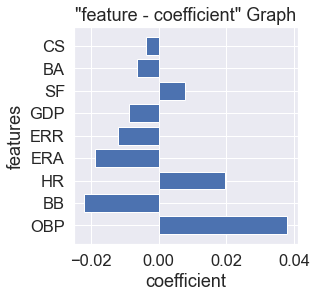

```python
### coefficients 를 시각화 합니다.
plt.figure(figsize = (4,4))

plt.barh(coefs_new['feature'], coefs_new['coefficients'])
plt.title('"feature - coefficient" Graph')
plt.xlabel('coefficient')
plt.ylabel('features')
plt.show()
```

```python
import statsmodels.api as sm

X_train2 = sm.add_constant(X_train)
### 회귀분석모형 수식을 간단하게 만들기 위해 다음과 같이 상수항을 독립변수 데이터에 추가하는 것을 상수항 결합(bias augmentation)작업이라고 합니다.
### ordinary least square 의 약자로, 거리의 최소값을 기준으로 구하는 함수입니다.

model2 = sm.OLS(y_train, X_train2).fit()
model2.summary()
```

OLS Regression Results

| Dep. Variable: | WR | R-squared: | 0.714 |
| --- | --- | --- | --- |
| Model: | OLS | Adj. R-squared: | 0.695 |
| Method: | Least Squares | F-statistic: | 37.18 |
| Date: | Fri, 25 Mar 2022 | Prob (F-statistic): | 2.78e-32 |
| Time: | 20:42:14 | Log-Likelihood: | 246.01 |
| No. Observations: | 144 | AIC: | -472.0 |
| Df Residuals: | 134 | BIC: | -442.3 |
| Df Model: | 9 |  |  |
| Covariance Type: | nonrobust |  |  |

|  | coef | std err | t | P>\|t\| | [0.025 | 0.975] |
| --- | --- | --- | --- | --- | --- | --- |
| const | 0.4981 | 0.004 | 130.872 | 0.000 | 0.491 | 0.506 |
| HR | 0.0197 | 0.005 | 3.711 | 0.000 | 0.009 | 0.030 |
| CS | -0.0038 | 0.004 | -0.892 | 0.374 | -0.012 | 0.005 |
| BA | -0.0063 | 0.006 | -1.013 | 0.313 | -0.019 | 0.006 |
| OBP | 0.0380 | 0.007 | 5.402 | 0.000 | 0.024 | 0.052 |
| GDP | -0.0088 | 0.004 | -2.123 | 0.036 | -0.017 | -0.001 |
| SF | 0.0078 | 0.004 | 1.902 | 0.059 | -0.000 | 0.016 |
| ERR | -0.0120 | 0.004 | -2.878 | 0.005 | -0.020 | -0.004 |
| ERA | -0.0188 | 0.004 | -4.600 | 0.000 | -0.027 | -0.011 |
| BB | -0.0219 | 0.004 | -5.001 | 0.000 | -0.031 | -0.013 |

| Omnibus: | 8.090 | Durbin-Watson: | 1.759 |
| --- | --- | --- | --- |
| Prob(Omnibus): | 0.018 | Jarque-Bera (JB): | 7.885 |
| Skew: | -0.502 | Prob(JB): | 0.0194 |
| Kurtosis: | 3.553 | Cond. No. | 3.55 |

Notes:  
[1] Standard Errors assume that the covariance matrix of the errors is correctly specified.

##### P>|t|

0.05 보다 작아야 유의미한데, CS 변수와 BA, SF 값은 주로 득점과 연결되는 것이 아니므로 무시를 해도 괜찮다고 판단됨

##### R-squared

R-squared 값은 결정 계수로 높을 수록 신뢰성 있는 데이터를 의미하고 이 프로젝트에서는 0.714라는 수치를 보인다.

##### 해석하기

1. "CS"(잡힌 도루 : p-value: 0.374)과 “BA”(타율: p-value:0.313), "SF"(희생 플라이: p-value:0.059)은 p-value가 0.05보다 크므로 유의미하지 않습니다.
2. 승률에 긍정적인 영향을 미칩니다.
   - "HR"(홈런 비율),
   - "OBP"(출루율)은  
     다른 변수의 값이 고정되었을 때, 해당 변수의 값이 클수록 승률이 높을 것임을 예측 가능
3. 승률에 부정적인 영향을 미칩니다.
   - "GDP"(병살타 비율),
   - "ERR"(실책률),
   - "ERA"(평균 자책점),
   - "BB"(볼넷 비율)은  
     다른 변수의 값이 고정되었을 때, 해당 변수의 값이 작을수록 승률이 높을 것임을 예측 가능

##### 모델 에측 결과 및 성능 평가 (예측결과를 가시화)

학습한 모델을 Test set에 적용하여 y값(“WR”)을 예측합니다. 예측 결과를 확인하기 위해 실제값과 예측값을 한 plot에 출력해 시각화

```python
### 예측 결과 시각화 (테스트 데이터)
df = pd.DataFrame({'actual': y_test, 'prediction': pred_test})
df = df.sort_values(by='actual').reset_index(drop=True)
df.head()

### reset_index() : 인덱스를 다시 처음부터 재배열
```

|  | actual | prediction |
| --- | --- | --- |
| 0 | 0.292 | 0.395514 |
| 1 | 0.317 | 0.299112 |
| 2 | 0.383 | 0.391451 |
| 3 | 0.395 | 0.437697 |
| 4 | 0.401 | 0.472106 |

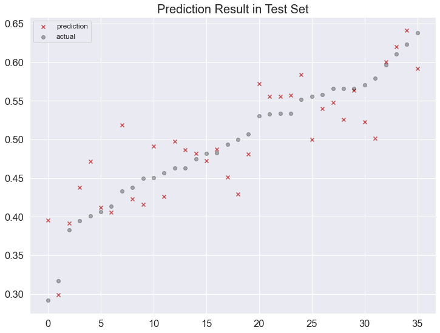

```python
plt.figure(figsize=(12, 9))
plt.scatter(df.index, df['prediction'], marker='x', color='r')
plt.scatter(df.index, df['actual'], alpha=0.3, marker='o', color='black')
plt.title("Prediction Result in Test Set", fontsize=20)
plt.legend(['prediction', 'actual'], fontsize=12)
plt.show()
```

```python
### R square - 정확도 기준
print(model.score(X_train, y_train))  # training set
print(model.score(X_test, y_test))  # test set
```

```
0.7140486521087737
0.7516585887381028
```

```python
# RMSE - Loss 값 (손실값)
from sklearn.metrics import mean_squared_error
from math import sqrt

# training set
pred_train = lr.predict(X_train)
print(sqrt(mean_squared_error(y_train, pred_train)))

# test set
print(sqrt(mean_squared_error(y_test, pred_test)))
```

```
0.04383332889889701
0.040636250121668153
```

##### 해설

> 테스트 데이터에서 예측 모델의 R-square 값은 0.75이고, RMSE 값은 0.04입니다.

### 결론

"HR"(홈런 비율)과 "OBP"(출루율)은 다른 변수의 값이 고정되었을 때, 해당 변수의 값이 클수록 승률이 높을 것임을 예측 가능하고,  
"GDP"(병살타 비율), "ERR"(실책률), "ERA"(평균 자책점), "BB"(볼넷 비율)은 다른 변수의 값이 고정되었을 때, 해당 변수의 값이 작을수록 승률이 높을 것임을 예측 가능했습니다.

또한 팀별로 요소들을 분석한 결과 보편적으로 실책률이 낮을 때 승률이 높아지는 것을 확인할 수 있었습니다.

> 이와 같은 결과가 나온 것으로 보아 승률 예측 문제는 Regression을 사용하여 푸는 것이 맞다고 생각했습니다.  
> 하지만, 승률에는 다양한 요소들이 작용하기 때문에 더 구체적인 분석이 필요할 것이라는 생각이 들었습니다.